# 05_reference_angle_deg

## 05_reference_angle_deg

#### Question

1. A unit circle was drawn centered at the origin. An initial ray was drawn from the origin through point (1,0). A terminal ray was drawn 113° counterclockwise from the initial ray.

   From the intersection of the circle and the terminal ray, a vertical line segment was drawn. Using the three vertices of intersection between the terminal ray, the vertical line, and the $x$-axis, a right triangle was drawn.

   The resulting right triangle has an acute angle at the origin. The measure of this acute angle is called a [reference angle](https://math.libretexts.org/Courses/Cosumnes_River_College/Math_373%3A_Trigonometry_for_Calculus/04%3A_Radian_Measure_and_the_Circular_Functions/4.01%3A_Reference_Angles). Find the measure, **in degrees**, of the reference angle. (The reference angle is always expressed as a positive angle.)

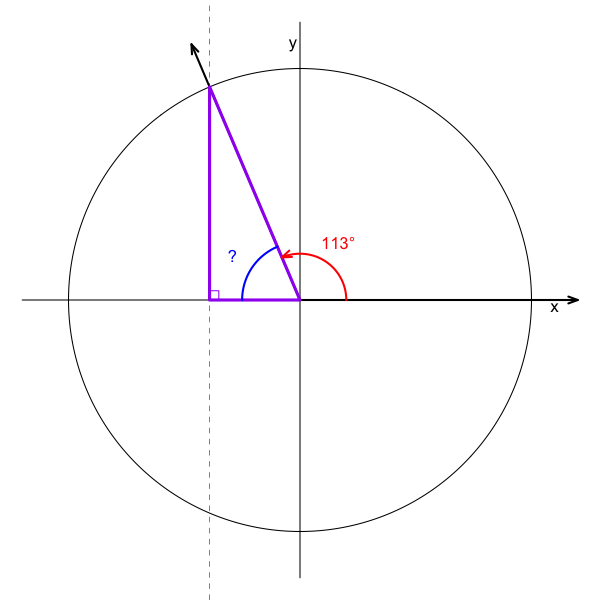

#### Question

2. A unit circle was drawn centered at the origin. An initial ray was drawn from the origin through point (1,0). A terminal ray was drawn 290° counterclockwise from the initial ray.

   From the intersection of the circle and the terminal ray, a vertical line segment was drawn. Using the three vertices of intersection between the terminal ray, the vertical line, and the $x$-axis, a right triangle was drawn.

   The resulting right triangle has an acute angle at the origin. The measure of this acute angle is called a [reference angle](https://math.libretexts.org/Courses/Cosumnes_River_College/Math_373%3A_Trigonometry_for_Calculus/04%3A_Radian_Measure_and_the_Circular_Functions/4.01%3A_Reference_Angles). Find the measure, **in degrees**, of the reference angle. (The reference angle is always expressed as a positive angle.)

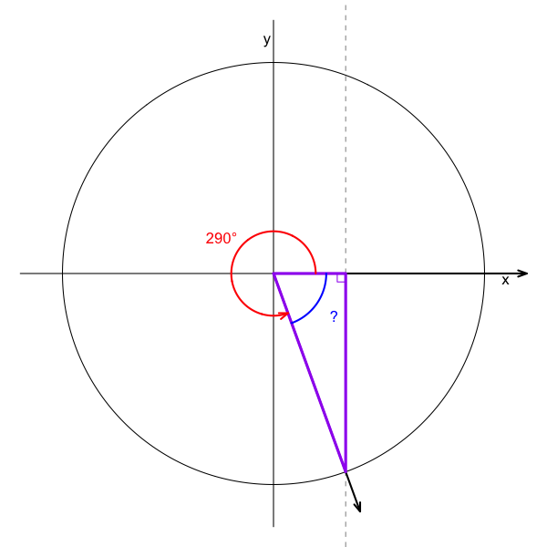

#### Question

3. A unit circle was drawn centered at the origin. An initial ray was drawn from the origin through point (1,0). A terminal ray was drawn 222° counterclockwise from the initial ray.

   From the intersection of the circle and the terminal ray, a vertical line segment was drawn. Using the three vertices of intersection between the terminal ray, the vertical line, and the $x$-axis, a right triangle was drawn.

   The resulting right triangle has an acute angle at the origin. The measure of this acute angle is called a [reference angle](https://math.libretexts.org/Courses/Cosumnes_River_College/Math_373%3A_Trigonometry_for_Calculus/04%3A_Radian_Measure_and_the_Circular_Functions/4.01%3A_Reference_Angles). Find the measure, **in degrees**, of the reference angle. (The reference angle is always expressed as a positive angle.)

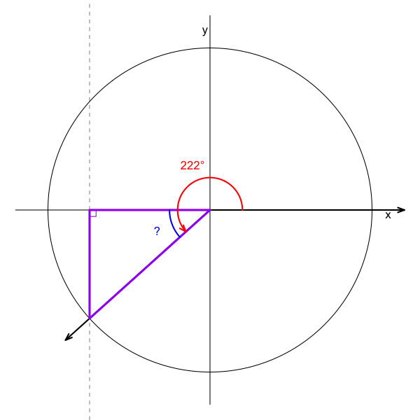

#### Question

4. A unit circle was drawn centered at the origin. An initial ray was drawn from the origin through point (1,0). A terminal ray was drawn 303° counterclockwise from the initial ray.

   From the intersection of the circle and the terminal ray, a vertical line segment was drawn. Using the three vertices of intersection between the terminal ray, the vertical line, and the $x$-axis, a right triangle was drawn.

   The resulting right triangle has an acute angle at the origin. The measure of this acute angle is called a [reference angle](https://math.libretexts.org/Courses/Cosumnes_River_College/Math_373%3A_Trigonometry_for_Calculus/04%3A_Radian_Measure_and_the_Circular_Functions/4.01%3A_Reference_Angles). Find the measure, **in degrees**, of the reference angle. (The reference angle is always expressed as a positive angle.)

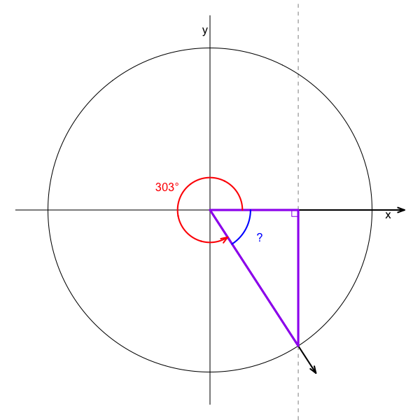

#### Question

5. A unit circle was drawn centered at the origin. An initial ray was drawn from the origin through point (1,0). A terminal ray was drawn 250° counterclockwise from the initial ray.

   From the intersection of the circle and the terminal ray, a vertical line segment was drawn. Using the three vertices of intersection between the terminal ray, the vertical line, and the $x$-axis, a right triangle was drawn.

   The resulting right triangle has an acute angle at the origin. The measure of this acute angle is called a [reference angle](https://math.libretexts.org/Courses/Cosumnes_River_College/Math_373%3A_Trigonometry_for_Calculus/04%3A_Radian_Measure_and_the_Circular_Functions/4.01%3A_Reference_Angles). Find the measure, **in degrees**, of the reference angle. (The reference angle is always expressed as a positive angle.)

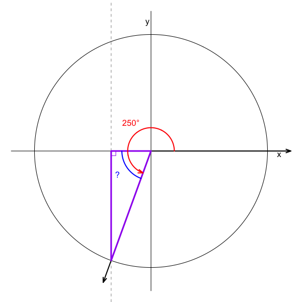

#### Question

6. A unit circle was drawn centered at the origin. An initial ray was drawn from the origin through point (1,0). A terminal ray was drawn 130° counterclockwise from the initial ray.

   From the intersection of the circle and the terminal ray, a vertical line segment was drawn. Using the three vertices of intersection between the terminal ray, the vertical line, and the $x$-axis, a right triangle was drawn.

   The resulting right triangle has an acute angle at the origin. The measure of this acute angle is called a [reference angle](https://math.libretexts.org/Courses/Cosumnes_River_College/Math_373%3A_Trigonometry_for_Calculus/04%3A_Radian_Measure_and_the_Circular_Functions/4.01%3A_Reference_Angles). Find the measure, **in degrees**, of the reference angle. (The reference angle is always expressed as a positive angle.)

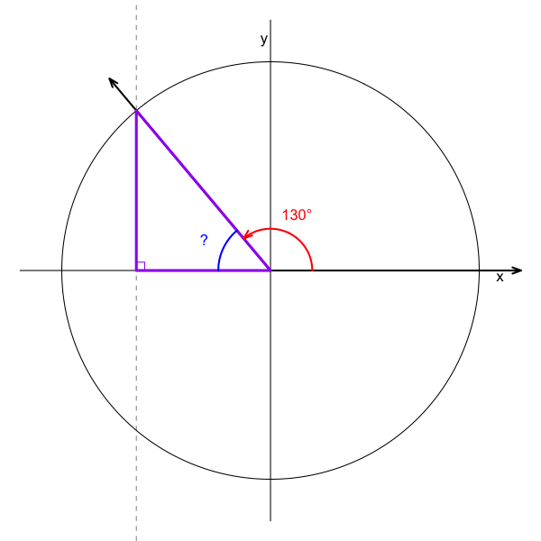

#### Question

7. A unit circle was drawn centered at the origin. An initial ray was drawn from the origin through point (1,0). A terminal ray was drawn 151° counterclockwise from the initial ray.

   From the intersection of the circle and the terminal ray, a vertical line segment was drawn. Using the three vertices of intersection between the terminal ray, the vertical line, and the $x$-axis, a right triangle was drawn.

   The resulting right triangle has an acute angle at the origin. The measure of this acute angle is called a [reference angle](https://math.libretexts.org/Courses/Cosumnes_River_College/Math_373%3A_Trigonometry_for_Calculus/04%3A_Radian_Measure_and_the_Circular_Functions/4.01%3A_Reference_Angles). Find the measure, **in degrees**, of the reference angle. (The reference angle is always expressed as a positive angle.)

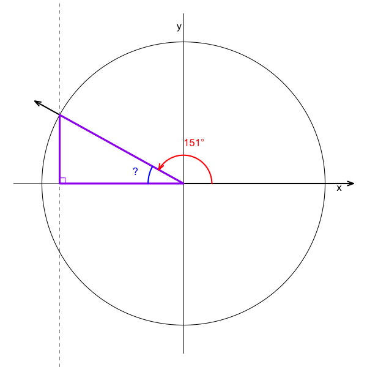

#### Question

8. A unit circle was drawn centered at the origin. An initial ray was drawn from the origin through point (1,0). A terminal ray was drawn 245° counterclockwise from the initial ray.

   From the intersection of the circle and the terminal ray, a vertical line segment was drawn. Using the three vertices of intersection between the terminal ray, the vertical line, and the $x$-axis, a right triangle was drawn.

   The resulting right triangle has an acute angle at the origin. The measure of this acute angle is called a [reference angle](https://math.libretexts.org/Courses/Cosumnes_River_College/Math_373%3A_Trigonometry_for_Calculus/04%3A_Radian_Measure_and_the_Circular_Functions/4.01%3A_Reference_Angles). Find the measure, **in degrees**, of the reference angle. (The reference angle is always expressed as a positive angle.)

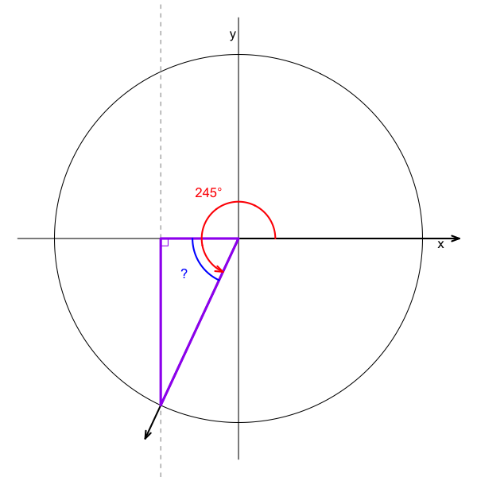